# Microbiome Key Taxa AI Report

This report is generated by **Microbiome Key Taxa AI**.

## Executive Summary

[output not shown]

## Data Quality Summary

Dataset overview

[output not shown]

[output not shown]

## Methods

### Alpha/Beta Diversity

Alpha diversity indices are computed per sample and compared between groups when a group variable is provided. Beta diversity is summarized using Bray-Curtis distance with ordination and PERMANOVA.

### Differential Abundance Analysis

Differential abundance identifies taxa associated with the group variable. Multiple-testing correction is applied (FDR). Results are descriptive and should be interpreted with study design context.

### Machine Learning (Random Forest)

Random Forest is used as a screening tool to rank taxa by importance for distinguishing groups. When sample size is small, results are treated as exploratory.

### Co-occurrence Network

A Spearman correlation network is built from genus-level abundances using correlation and FDR thresholds. Co-occurrence reflects correlation patterns and does not imply direct interaction.

### Key Taxa Score

KeyTaxaScore integrates available evidence sources (differential, ML importance, and network centrality) using weighted, normalized components. If a taxon lacks one evidence source, the score is computed from the remaining available evidence for that taxon and marked as exploratory via the evidence fields.

### AI Interpretation

This report includes pre-generated AI interpretation text when available. Phase 8 does not call any LLM API during report rendering.

## Co-occurrence Network Analysis

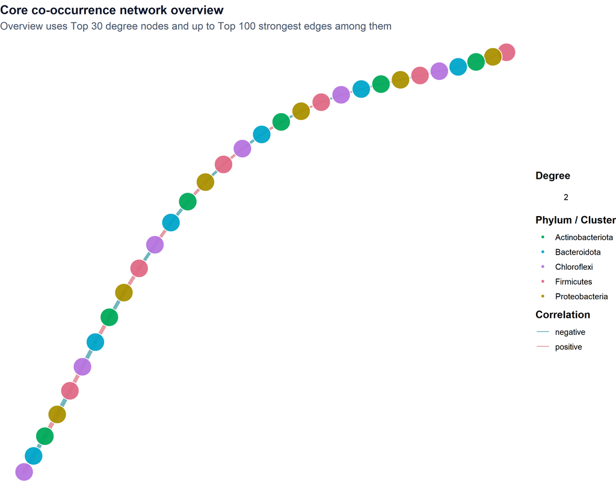

Figure 6. Co-occurrence network (Spearman correlation; co-occurrence does not imply direct interaction).

Co-occurrence does not imply direct interaction.

## Key Taxa Score

KeyTaxaScore formula (Phase 7):

```
KeyTaxaScore =
0.4 * DifferentialScore +
0.4 * MLImportanceScore +
0.2 * NetworkCentralityScore

DifferentialScore = normalized(-log10(FDR) * abs(log2FC))
MLImportanceScore = normalized(Random Forest importance)
NetworkCentralityScore = normalized(degree + betweenness)
```

## Reproducibility Record

**Job dir:** D:/Microbiome Key Taxa AI/results/job_20260614_145009_c48t80

**R version:** R version 4.6.0 (2026-04-24 ucrt)

**microeco version:** 2.2.0

**Generated outputs (expected):**

- tables/alpha_diversity.csv : MISSING
- tables/beta_permanova.csv : MISSING
- tables/differential_taxa.csv : MISSING
- tables/ml_feature_importance.csv : MISSING
- tables/network_nodes.csv : MISSING
- tables/key_taxa_score.csv : MISSING
- figures/alpha_shannon_boxplot.png : MISSING
- figures/beta_pcoa_bray.png : MISSING
- figures/diff_taxa_barplot.png : MISSING
- figures/ml_importance.png : MISSING
- figures/network_plot.png : OK
- figures/key_taxa_score_barplot.png : MISSING
- json/key_taxa_summary.json : MISSING
- ai/diff_interpretation.md : MISSING

**AI interpretation rule summary:** Phase 8 does not call any LLM API; it only includes pre-generated markdown/JSON outputs when present.

This report was generated on 2026-06-14 using Quarto.